# Generating phenotypes from 1KGP

# Working with synthetic data:

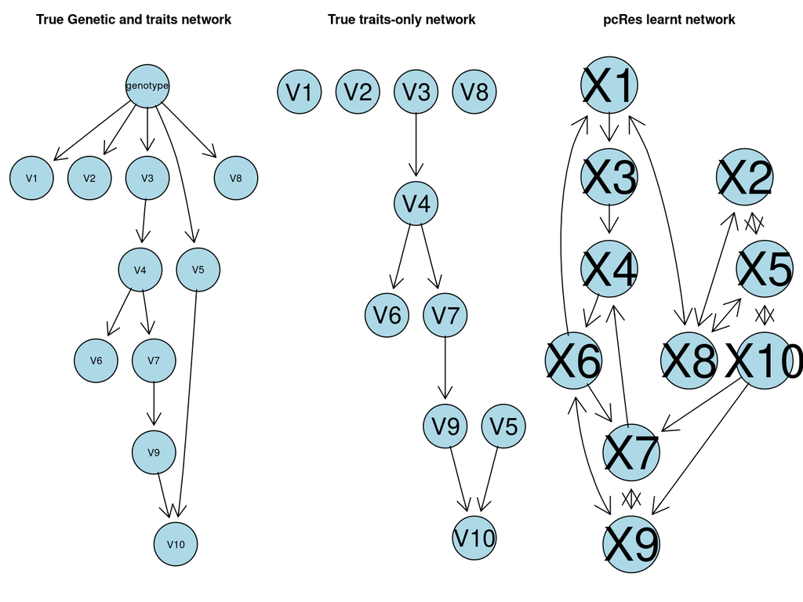

```
## pc(suffStat = list(C = cor(res), n = nrow(res)), indepTest = gaussCItest,
##     alpha = alpha, labels = colnames(suffStat)[-1], m.max = m.max,
##     u2pd = "relaxed", skel.method = "stable", conservative = FALSE,
##     maj.rule = TRUE, solve.confl = TRUE, verbose = verbose)
```

```
## [1] 1
## [1] 2
## [1] 3
## [1] 4
## [1] 5
## [1] "data.syn$true_dag$dag vs pcRes(K =  data.syn$K ) run 5 times"
```

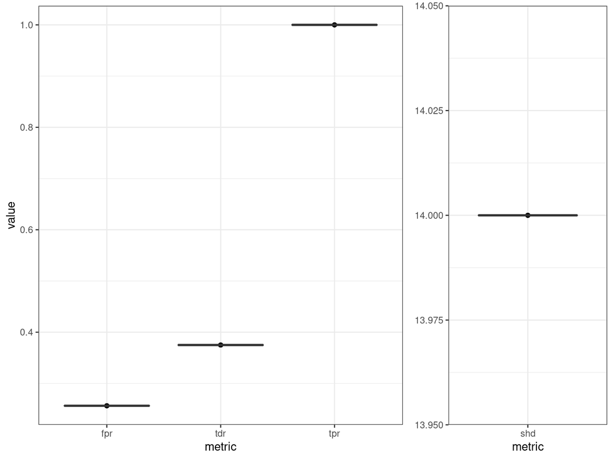

# conclusions:

These plots show:

- The genotypes effects are not learnt by `pcRes`, this follows from using the `pc` algorithm that does not account for confounding. It means we expect a bit higher level of errors in learning the network, and we see this when comparing with the *traits-only network*
- Yet, we do see those traits with direct genetic effect to be related to each other in our learnt network.
- We also see in the learnt network that the edges between traits with no direct effects to have been largely learnt (albiet with the wrong orientation at times).

# Idea 1:

- Consider a confounding-friendly algorithm (something other than pc)

  ```
  ## # A tibble: 2 x 3
  ##   Method              Abbreviation Remarks
  ##   <chr>               <chr>        <chr>
  ## 1 Fast Causal Infere… fci          computationally unfeasible for large graphs
  ## 2 Really Fast Causal… rfci         much faster, output slightly less informativ…
  ```

- Both these methods are consistent in sparse dimensional settings
- Both are based on the pc algorith, and similarly, have order-independent variants
- With the data at hand

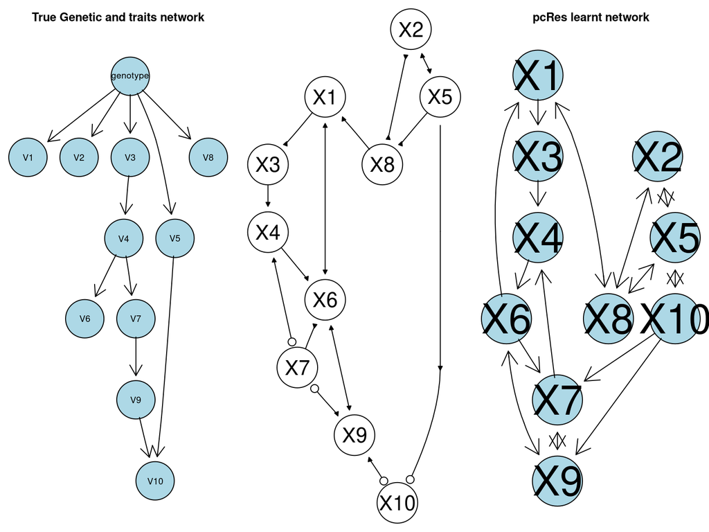

```
## pc(suffStat = list(C = cor(res), n = nrow(res)), indepTest = gaussCItest,
##     alpha = alpha, labels = colnames(suffStat)[-1], m.max = m.max,
##     u2pd = "relaxed", skel.method = "stable", conservative = FALSE,
##     maj.rule = TRUE, solve.confl = TRUE, verbose = verbose)
```

```
## [1] 1
## [1] 2
## [1] 3
## [1] 4
## [1] 5
## [1] "data.syn$true_dag$dag vs pcRes(K =  data.syn$K ) run 5 times"
```

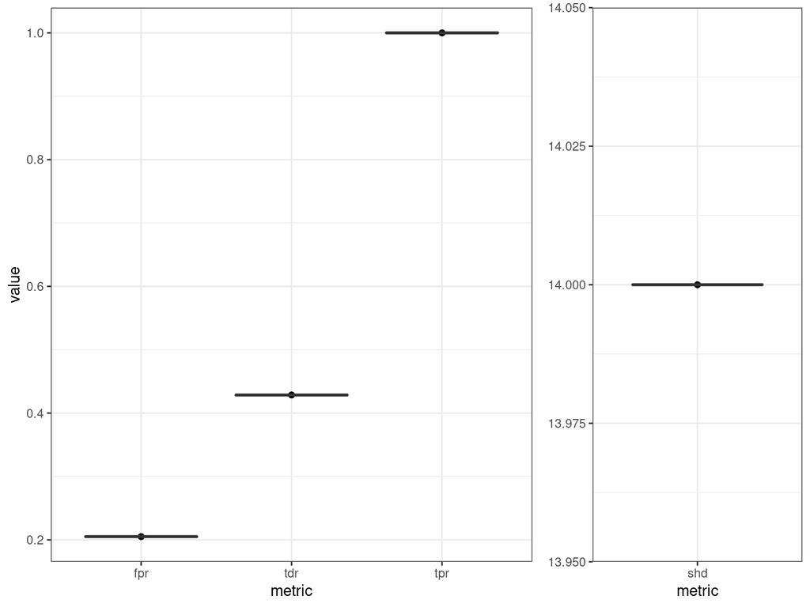

- What’s the right way to evaluate in this case? I’m caluclating SHD, FPR, .. etc, by converting the adjacency matrix into a graph object first, ignoring all edge info (similar to how it is done with pcRes evals). In essence, this ignores different possible values on the adjacency matrix:
- PAG (column index)
  - 0: No edge
  - 1: Circle
  - 2: Arrowhead
  - 3: Tail
- CPDAG (row index)
  - 0: No edge or tail
  - 1: Arrowhead

```r
PAG
  amat[a,b] = 2  and  amat[b,a] = 3   implies   a --> b.
  amat[a,b] = 3  and  amat[b,a] = 2   implies   a <-- b.
  amat[a,b] = 2  and  amat[b,a] = 2   implies   a <-> b.
  amat[a,b] = 1  and  amat[b,a] = 3   implies   a --o b.
  amat[a,b] = 0  and  amat[b,a] = 0   implies   a     b.

CPDAG:
  amat[a,b] = 0  and  amat[b,a] = 1   implies a --> b.
  amat[a,b] = 1  and  amat[b,a] = 0   implies a <-- b.
  amat[a,b] = 0  and  amat[b,a] = 0   implies a     b.
  amat[a,b] = 1  and  amat[b,a] = 1   implies a --- b.
```

# idea 2:

- learn a complete network with `pcgen` not pcRes
  - initially, we didn’t take this route, because the mouse dataset contains covariates, and it is easier to work with them away from genotype effects.

# idea 3:

- compare with results from learning a MVLMM!